# Assignment 7

## Esra Bilir

### ID: 0032772

#### Deadline: on June 07, 23:59 o'clock (Turkish local time).

#### send me (ahurriyetoglu@ku.edu.tr), a notebook in both .ipynb and HTML formats that contain solutions to the exercises below.

```python
# First of all, import the pandas library

import pandas as pd
```

# Run the code "pd.options.display.max_colwidth = 500" in order to see all content in Pandas cells up to 500 characters."

```python
pd.options.display.max_colwidth = 500
```

### 1- How many lines are there in the dataframe? How much space does it consume in your memory?

```python
twitter_data = pd.read_csv("202005171549_corona_tweets.csv")

twitter_data
```

|  | Unnamed: 0 | Unnamed: 0.1 | coordinates | country | created_at | device | entity_hashtags | entity_mentions | entity_type | entity_urls | id_str | in_reply_to_user_id | is_retweet | screen_name | text | tweet_location | user_followers | user_following | user_id | user_location |
| --- | --- | --- | --- | --- | --- | --- | --- | --- | --- | --- | --- | --- | --- | --- | --- | --- | --- | --- | --- | --- |
| 0 | 34646 | 34646 | NaN | NaN | 2020-03-03 02:49:50 | Twitter for iPhone | [] | [] | NaN | ['twitter.com/i/web/status/1…'] | 1234672302903590913 | NaN | False | Manny_Alicandro | Every 3 days? Coronavirus in NY? Workers will disinfect parts of subways, buses every 72 hours as New York reports… https://t.co/sxVkmdTeME | NaN | 9125 | 4872 | 992623688028774400 | NY |
| 1 | 34647 | 34647 | NaN | NaN | 2020-03-03 02:49:50 | Twitter for Android | [] | ['shobey_edits'] | NaN | [] | 1234672302647738370 | NaN | True | wodzd | RT @shobey_edits: sent a mail to marvel ent, regarding dogyul and dongpyo's fm asking about any update in-line with covid-19 and finally go… | NaN | 3123 | 3103 | 1086492406466277377 | 𝐗𝐎𝐧𝐞𝐈𝐭 |
| 2 | 34648 | 34648 | NaN | NaN | 2020-03-03 02:49:50 | Twitter for iPhone | [] | ['realDonaldTrump'] | NaN | ['twitter.com/i/web/status/1…'] | 1234672301888532480 | 25073877.0 | False | mom2speak1 | @realDonaldTrump Wow, a nice incubator for COVID-19! But hey, what do epidemiologists know, right Donny? Make Ameri… https://t.co/FCk8mUHmKe | NaN | 313 | 1149 | 800391394191810560 | United States |
| 3 | 34649 | 34649 | NaN | NaN | 2020-03-03 02:49:50 | Twitter Web App | [] | ['uk_domain_names'] | NaN | [] | 1234672301712347136 | NaN | True | lazaroumterror | RT @uk_domain_names: "UK and Scottish government modelling shows that the economic and fiscal costs of a Covid-19 epidemic could be on a pa… | NaN | 3871 | 3935 | 19881915 | London |
| 4 | 34650 | 34650 | NaN | NaN | 2020-03-03 02:49:50 | Twitter Web App | [] | ['LanceHoward70'] | NaN | [] | 1234672300584103936 | NaN | True | astro_stephen13 | RT @LanceHoward70: This 👇 is the leader of the free world, folks. A man who does not understand that the “flu shot” will not work as a vacc… | NaN | 538 | 367 | 148663 | Georgia, USA |
| ... | ... | ... | ... | ... | ... | ... | ... | ... | ... | ... | ... | ... | ... | ... | ... | ... | ... | ... | ... | ... |
| 541788 | 1048570 | 1050544 | NaN | NaN | 2020-02-29 17:56:27 | Twitter for Android | ['COVID19'] | ['Laurie_Garrett'] | NaN | [] | 1233813296135987201 | NaN | True | Who_IsM | RT @Laurie_Garrett: If the US govt keeps billing Americans $1000s for evacuations and #COVID19 quarantine, people who are infected will hid… | NaN | 1937 | 4996 | 968640829 | Earth |
| 541789 | 1048571 | 1050545 | NaN | NaN | 2020-02-29 17:56:27 | Twitter for iPhone | ['coronavirus'] | ['tancredipalmeri'] | NaN | [] | 1233813295561355264 | NaN | True | orionmaggi | RT @tancredipalmeri: The #coronavirus cases in Italy: (accumulative count) Day1: 14cases/1dead Day2: 76/2 Day3: 153/3 Day4: 231/7 Day5: 37… | NaN | 162 | 587 | 794726696 | New England |
| 541790 | 1048572 | 1050546 | NaN | NaN | 2020-02-29 17:56:25 | Twitter for iPhone | [] | ['treasonstickers'] | NaN | [] | 1233813288930226176 | NaN | True | Peace_NH | RT @treasonstickers: FUN FACT: Donald Trump is the first President in US history to get impeached, botch a pandemic quarantine and cause a… | NaN | 594 | 434 | 2511294116 | New Hampshire |
| 541791 | 1048573 | 1050547 | NaN | NaN | 2020-02-29 17:56:25 | Twitter for iPhone | [] | ['washingtonpost'] | NaN | [] | 1233813288644792320 | NaN | True | avoidchaos | RT @washingtonpost: DHS employee told to report to work in Newark after China travel, in violation of coronavirus quarantine, complaints sa… | NaN | 766 | 518 | 1177196383 | Los Angeles, CA |
| 541792 | 1048574 | 1050548 | NaN | NaN | 2020-02-29 17:56:25 | Twitter for iPhone | [] | ['delta_su', 'bajas_k'] | NaN | [] | 1233813287852097538 | NaN | True | NewImproved9 | RT @delta_su: @bajas_k Maybe he is in self quarantine from his travels,to hold hands with leader of Iran.He disgusted Canadians as he bowed… | NaN | 3507 | 3591 | 944714037241114624 | British Columbia, Canada |

541793 rows × 20 columns

```python
"""

The number of lines is 541793

"""

len(twitter_data)
```

```
541793
```

```python
"""

The space that the dataframe consume in my memory by each column

"""

twitter_data.memory_usage()
```

```
Index                      128
Unnamed: 0             4334344
Unnamed: 0.1           4334344
coordinates            4334344
country                4334344
created_at             4334344
device                 4334344
entity_hashtags        4334344
entity_mentions        4334344
entity_type            4334344
entity_urls            4334344
id_str                 4334344
in_reply_to_user_id    4334344
is_retweet              541793
screen_name            4334344
text                   4334344
tweet_location         4334344
user_followers         4334344
user_following         4334344
user_id                4334344
user_location          4334344
dtype: int64
```

```python
"""

The total space that the dataframe consume in my memory

"""

twitter_data.memory_usage(index=True).sum()
```

```
82894457
```

### 2- What are the column names?

```python
list(twitter_data.columns.values)
```

```
['Unnamed: 0',
 'Unnamed: 0.1',
 'coordinates',
 'country',
 'created_at',
 'device',
 'entity_hashtags',
 'entity_mentions',
 'entity_type',
 'entity_urls',
 'id_str',
 'in_reply_to_user_id',
 'is_retweet',
 'screen_name',
 'text',
 'tweet_location',
 'user_followers',
 'user_following',
 'user_id',
 'user_location']
```

### 3- Identify the most tweeting 50 users. The value_counts() method will help you

```python
user_id_data = twitter_data['user_id'].value_counts()

user_id_data.head(50)
```

```
19087092               312
369315889              309
246134823              275
1231590638             265
17694306               242
886675788              179
1133549569436987393    145
19708473               140
757358178044678144     133
753571509080174592     130
289118612              128
212457705              114
58371354               111
1222133856469504000    111
29519681               104
```

[output cut: 36 more lines]

### 4- Plot a histogram of the 50 most tweeting users. Do not forget to include an xlabel, ylabel, and a title on your figure.

```python
# Import the necessary library

import matplotlib.pyplot as plt
```

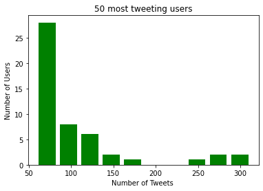

```python
x = user_id_data.head(50)

#the default bins is 10 since not specified I used the default value

y_axis, x_axis, bar = plt.hist(x, color="g", rwidth=0.8, orientation="vertical")
plt.title("50 most tweeting users")
plt.xlabel("Number of Tweets ")
plt.ylabel("Number of Users")

plt.show()
```

```python
y_axis
```

```
array([28.,  8.,  6.,  2.,  1.,  0.,  0.,  1.,  2.,  2.])
```

```python
len(y_axis)
```

```
10
```

```python
x_axis
```

```
array([ 59. ,  84.3, 109.6, 134.9, 160.2, 185.5, 210.8, 236.1, 261.4,
       286.7, 312. ])
```

```python
len(x_axis)
```

```
11
```

```python
bar
```

```
<BarContainer object of 10 artists>
```

### 5- Identify duplicate tweets based on the 'text' field.

```python
duplicated_text = twitter_data[twitter_data.duplicated(["text"])]

duplicated_text
```

|  | Unnamed: 0 | Unnamed: 0.1 | coordinates | country | created_at | device | entity_hashtags | entity_mentions | entity_type | entity_urls | id_str | in_reply_to_user_id | is_retweet | screen_name | text | tweet_location | user_followers | user_following | user_id | user_location |
| --- | --- | --- | --- | --- | --- | --- | --- | --- | --- | --- | --- | --- | --- | --- | --- | --- | --- | --- | --- | --- |
| 12 | 34658 | 34658 | NaN | NaN | 2020-03-03 02:49:47 | Twitter for Android | [] | ['NYGovCuomo'] | NaN | [] | 1234672290626859009 | NaN | True | NowItsOurTurn1 | RT @NYGovCuomo: BREAKING: I am announcing a new directive requiring NY health insurers to waive cost sharing associated with testing for #c… | NaN | 763 | 1106 | 1047932292537057280 | NaN |
| 14 | 34660 | 34660 | NaN | NaN | 2020-03-03 02:49:47 | Twitter Web App | [] | ['NYGovCuomo'] | NaN | [] | 1234672287103631361 | NaN | True | blinxeto | RT @NYGovCuomo: BREAKING: I am announcing a new directive requiring NY health insurers to waive cost sharing associated with testing for #c… | NaN | 97 | 50 | 1144799004972257287 | NaN |
| 15 | 34661 | 34661 | NaN | NaN | 2020-03-03 02:49:46 | Twitter for iPhone | [] | ['NYGovCuomo'] | NaN | [] | 1234672285929226240 | NaN | True | heyitsallcool | RT @NYGovCuomo: BREAKING: I am announcing a new directive requiring NY health insurers to waive cost sharing associated with testing for #c… | NaN | 592 | 552 | 4710791536 | NaN |
| 18 | 34664 | 34664 | NaN | NaN | 2020-03-03 02:49:46 | Twitter for Android | [] | ['shobey_edits'] | NaN | [] | 1234672284784185344 | NaN | True | luizywooya | RT @shobey_edits: sent a mail to marvel ent, regarding dogyul and dongpyo's fm asking about any update in-line with covid-19 and finally go… | NaN | 3723 | 3771 | 1197833978721341441 | \n\nᴿʸᵉᵒⁿˢᵉᵘⁿᵍ🍑ᵐᵘˡᶠᵃⁿᵈ🍕ᵉⁿᵍ/ⁱⁿᵈ |
| 19 | 34665 | 34665 | NaN | NaN | 2020-03-03 02:49:46 | Twitter for Android | [] | ['shobey_edits'] | NaN | [] | 1234672284448645120 | NaN | True | ljhuyeuye | RT @shobey_edits: sent a mail to marvel ent, regarding dogyul and dongpyo's fm asking about any update in-line with covid-19 and finally go… | NaN | 489 | 1152 | 420826863 | x98it |
| ... | ... | ... | ... | ... | ... | ... | ... | ... | ... | ... | ... | ... | ... | ... | ... | ... | ... | ... | ... | ... |
| 541788 | 1048570 | 1050544 | NaN | NaN | 2020-02-29 17:56:27 | Twitter for Android | ['COVID19'] | ['Laurie_Garrett'] | NaN | [] | 1233813296135987201 | NaN | True | Who_IsM | RT @Laurie_Garrett: If the US govt keeps billing Americans $1000s for evacuations and #COVID19 quarantine, people who are infected will hid… | NaN | 1937 | 4996 | 968640829 | Earth |
| 541789 | 1048571 | 1050545 | NaN | NaN | 2020-02-29 17:56:27 | Twitter for iPhone | ['coronavirus'] | ['tancredipalmeri'] | NaN | [] | 1233813295561355264 | NaN | True | orionmaggi | RT @tancredipalmeri: The #coronavirus cases in Italy: (accumulative count) Day1: 14cases/1dead Day2: 76/2 Day3: 153/3 Day4: 231/7 Day5: 37… | NaN | 162 | 587 | 794726696 | New England |
| 541790 | 1048572 | 1050546 | NaN | NaN | 2020-02-29 17:56:25 | Twitter for iPhone | [] | ['treasonstickers'] | NaN | [] | 1233813288930226176 | NaN | True | Peace_NH | RT @treasonstickers: FUN FACT: Donald Trump is the first President in US history to get impeached, botch a pandemic quarantine and cause a… | NaN | 594 | 434 | 2511294116 | New Hampshire |
| 541791 | 1048573 | 1050547 | NaN | NaN | 2020-02-29 17:56:25 | Twitter for iPhone | [] | ['washingtonpost'] | NaN | [] | 1233813288644792320 | NaN | True | avoidchaos | RT @washingtonpost: DHS employee told to report to work in Newark after China travel, in violation of coronavirus quarantine, complaints sa… | NaN | 766 | 518 | 1177196383 | Los Angeles, CA |
| 541792 | 1048574 | 1050548 | NaN | NaN | 2020-02-29 17:56:25 | Twitter for iPhone | [] | ['delta_su', 'bajas_k'] | NaN | [] | 1233813287852097538 | NaN | True | NewImproved9 | RT @delta_su: @bajas_k Maybe he is in self quarantine from his travels,to hold hands with leader of Iran.He disgusted Canadians as he bowed… | NaN | 3507 | 3591 | 944714037241114624 | British Columbia, Canada |

420992 rows × 20 columns

### 6- Remove duplicate tweets based on the 'text' field. How many tweets do you have now?

```python
twitter_data.drop_duplicates(subset="text", inplace=True)

twitter_data
```

|  | Unnamed: 0 | Unnamed: 0.1 | coordinates | country | created_at | device | entity_hashtags | entity_mentions | entity_type | entity_urls | id_str | in_reply_to_user_id | is_retweet | screen_name | text | tweet_location | user_followers | user_following | user_id | user_location |
| --- | --- | --- | --- | --- | --- | --- | --- | --- | --- | --- | --- | --- | --- | --- | --- | --- | --- | --- | --- | --- |
| 0 | 34646 | 34646 | NaN | NaN | 2020-03-03 02:49:50 | Twitter for iPhone | [] | [] | NaN | ['twitter.com/i/web/status/1…'] | 1234672302903590913 | NaN | False | Manny_Alicandro | Every 3 days? Coronavirus in NY? Workers will disinfect parts of subways, buses every 72 hours as New York reports… https://t.co/sxVkmdTeME | NaN | 9125 | 4872 | 992623688028774400 | NY |
| 1 | 34647 | 34647 | NaN | NaN | 2020-03-03 02:49:50 | Twitter for Android | [] | ['shobey_edits'] | NaN | [] | 1234672302647738370 | NaN | True | wodzd | RT @shobey_edits: sent a mail to marvel ent, regarding dogyul and dongpyo's fm asking about any update in-line with covid-19 and finally go… | NaN | 3123 | 3103 | 1086492406466277377 | 𝐗𝐎𝐧𝐞𝐈𝐭 |
| 2 | 34648 | 34648 | NaN | NaN | 2020-03-03 02:49:50 | Twitter for iPhone | [] | ['realDonaldTrump'] | NaN | ['twitter.com/i/web/status/1…'] | 1234672301888532480 | 25073877.0 | False | mom2speak1 | @realDonaldTrump Wow, a nice incubator for COVID-19! But hey, what do epidemiologists know, right Donny? Make Ameri… https://t.co/FCk8mUHmKe | NaN | 313 | 1149 | 800391394191810560 | United States |
| 3 | 34649 | 34649 | NaN | NaN | 2020-03-03 02:49:50 | Twitter Web App | [] | ['uk_domain_names'] | NaN | [] | 1234672301712347136 | NaN | True | lazaroumterror | RT @uk_domain_names: "UK and Scottish government modelling shows that the economic and fiscal costs of a Covid-19 epidemic could be on a pa… | NaN | 3871 | 3935 | 19881915 | London |
| 4 | 34650 | 34650 | NaN | NaN | 2020-03-03 02:49:50 | Twitter Web App | [] | ['LanceHoward70'] | NaN | [] | 1234672300584103936 | NaN | True | astro_stephen13 | RT @LanceHoward70: This 👇 is the leader of the free world, folks. A man who does not understand that the “flu shot” will not work as a vacc… | NaN | 538 | 367 | 148663 | Georgia, USA |
| ... | ... | ... | ... | ... | ... | ... | ... | ... | ... | ... | ... | ... | ... | ... | ... | ... | ... | ... | ... | ... |
| 541769 | 1048551 | 1050525 | NaN | NaN | 2020-02-29 17:56:51 | Twitter for iPhone | [] | [] | NaN | [] | 1233813395008360448 | NaN | False | MANLIKEAFRIKA | All These People Choosing To Travel All Around The Place Right Now Need To Stay In Quarantine When The Time Comes 😤😷 | NaN | 271 | 262 | 148903406 | NaN |
| 541777 | 1048559 | 1050533 | NaN | NaN | 2020-02-29 17:56:44 | Twitter for Android | [] | [] | NaN | ['rawstory.com/2020/02/quaran…'] | 1233813365455192064 | NaN | False | timmins316 | Quarantine patient assures Fox News coronavirus isn’t ‘scary’ because he has no symptoms https://t.co/MtdTjlReX7 | NaN | 2069 | 5001 | 27076961 | Kingston, Ontario |
| 541778 | 1048560 | 1050534 | NaN | NaN | 2020-02-29 17:56:43 | Twitter Web App | [] | [] | NaN | ['twitter.com/i/web/status/1…'] | 1233813362586398729 | NaN | False | the_stormclam | America had better figure out the answer to "who pays for the expenses of forced quarantine" on a national scale an… https://t.co/610bE2e4Ny | NaN | 138 | 518 | 895746394585157632 | NaN |
| 541785 | 1048567 | 1050541 | NaN | NaN | 2020-02-29 17:56:34 | Twitter Web App | [] | ['DirtyCopHunter', 'tedlieu', 'realDonaldTrump'] | NaN | ['twitter.com/i/web/status/1…'] | 1233813323579301888 | 120978797.0 | False | zingertat | @DirtyCopHunter @tedlieu @realDonaldTrump if it is just the flu, why do countries feel the need to quarantine a who… https://t.co/nvyf9DoJ6t | NaN | 31 | 44 | 1191480824748752897 | NaN |
| 541786 | 1048568 | 1050542 | NaN | Kenya | 2020-02-29 17:56:32 | Twitter for Android | [] | ['Mwirigi'] | NaN | [] | 1233813318357393413 | 16463639.0 | False | mougendi | @Mwirigi Umeenda self quarantine kwanza? | Nairobi, Kenya | 6873 | 3065 | 30274860 | Nairobi, Kenya |

120801 rows × 20 columns

```python
"""

ANSWER: Now, we have 120801 Tweets where initially we had 541793

"""

len(twitter_data)
```

```
120801
```

### 7- Replace all users names in the 'text' field with the usrusr token. You need to write a regular expression that identify user names and use the replace method to replace it with the 'usrusr' token.

For instance:

"Are you there @ahurriyetoglu" should be "Are you there usrusr"

```python
username="@[a-zA-Z0-9_]{0,15}"

twitter_data["text"]=twitter_data["text"].replace(to_replace =username, value = "usrusr", regex = True)


twitter_data.head()
```

|  | Unnamed: 0 | Unnamed: 0.1 | coordinates | country | created_at | device | entity_hashtags | entity_mentions | entity_type | entity_urls | id_str | in_reply_to_user_id | is_retweet | screen_name | text | tweet_location | user_followers | user_following | user_id | user_location |
| --- | --- | --- | --- | --- | --- | --- | --- | --- | --- | --- | --- | --- | --- | --- | --- | --- | --- | --- | --- | --- |
| 0 | 34646 | 34646 | NaN | NaN | 2020-03-03 02:49:50 | Twitter for iPhone | [] | [] | NaN | ['twitter.com/i/web/status/1…'] | 1234672302903590913 | NaN | False | Manny_Alicandro | Every 3 days? Coronavirus in NY? Workers will disinfect parts of subways, buses every 72 hours as New York reports… https://t.co/sxVkmdTeME | NaN | 9125 | 4872 | 992623688028774400 | NY |
| 1 | 34647 | 34647 | NaN | NaN | 2020-03-03 02:49:50 | Twitter for Android | [] | ['shobey_edits'] | NaN | [] | 1234672302647738370 | NaN | True | wodzd | RT usrusr: sent a mail to marvel ent, regarding dogyul and dongpyo's fm asking about any update in-line with covid-19 and finally go… | NaN | 3123 | 3103 | 1086492406466277377 | 𝐗𝐎𝐧𝐞𝐈𝐭 |
| 2 | 34648 | 34648 | NaN | NaN | 2020-03-03 02:49:50 | Twitter for iPhone | [] | ['realDonaldTrump'] | NaN | ['twitter.com/i/web/status/1…'] | 1234672301888532480 | 25073877.0 | False | mom2speak1 | usrusr Wow, a nice incubator for COVID-19! But hey, what do epidemiologists know, right Donny? Make Ameri… https://t.co/FCk8mUHmKe | NaN | 313 | 1149 | 800391394191810560 | United States |
| 3 | 34649 | 34649 | NaN | NaN | 2020-03-03 02:49:50 | Twitter Web App | [] | ['uk_domain_names'] | NaN | [] | 1234672301712347136 | NaN | True | lazaroumterror | RT usrusr: "UK and Scottish government modelling shows that the economic and fiscal costs of a Covid-19 epidemic could be on a pa… | NaN | 3871 | 3935 | 19881915 | London |
| 4 | 34650 | 34650 | NaN | NaN | 2020-03-03 02:49:50 | Twitter Web App | [] | ['LanceHoward70'] | NaN | [] | 1234672300584103936 | NaN | True | astro_stephen13 | RT usrusr: This 👇 is the leader of the free world, folks. A man who does not understand that the “flu shot” will not work as a vacc… | NaN | 538 | 367 | 148663 | Georgia, USA |

### 8- Replace all URLs with 'urlurl' token in the 'text' column.

For instance:

"Please visit http://ku.edu.tr" should be "Please visit urlurl".

```python
url="(https?:\/\/(?:www\.|(?!www))[a-zA-Z0-9][a-zA-Z0-9-]+[a-zA-Z0-9]\.[^\s]{2,}|www\.[a-zA-Z0-9][a-zA-Z0-9-]+[a-zA-Z0-9]\.[^\s]{2,}|https?:\/\/(?:www\.|(?!www))[a-zA-Z0-9]+\.[^\s]{2,}|www\.[a-zA-Z0-9]+\.[^\s]{2,})"
twitter_data["text"]=twitter_data["text"].replace(to_replace =url, value = "urlurl", regex = True)

twitter_data.head()
```

|  | Unnamed: 0 | Unnamed: 0.1 | coordinates | country | created_at | device | entity_hashtags | entity_mentions | entity_type | entity_urls | id_str | in_reply_to_user_id | is_retweet | screen_name | text | tweet_location | user_followers | user_following | user_id | user_location |
| --- | --- | --- | --- | --- | --- | --- | --- | --- | --- | --- | --- | --- | --- | --- | --- | --- | --- | --- | --- | --- |
| 0 | 34646 | 34646 | NaN | NaN | 2020-03-03 02:49:50 | Twitter for iPhone | [] | [] | NaN | ['twitter.com/i/web/status/1…'] | 1234672302903590913 | NaN | False | Manny_Alicandro | Every 3 days? Coronavirus in NY? Workers will disinfect parts of subways, buses every 72 hours as New York reports… urlurl | NaN | 9125 | 4872 | 992623688028774400 | NY |
| 1 | 34647 | 34647 | NaN | NaN | 2020-03-03 02:49:50 | Twitter for Android | [] | ['shobey_edits'] | NaN | [] | 1234672302647738370 | NaN | True | wodzd | RT usrusr: sent a mail to marvel ent, regarding dogyul and dongpyo's fm asking about any update in-line with covid-19 and finally go… | NaN | 3123 | 3103 | 1086492406466277377 | 𝐗𝐎𝐧𝐞𝐈𝐭 |
| 2 | 34648 | 34648 | NaN | NaN | 2020-03-03 02:49:50 | Twitter for iPhone | [] | ['realDonaldTrump'] | NaN | ['twitter.com/i/web/status/1…'] | 1234672301888532480 | 25073877.0 | False | mom2speak1 | usrusr Wow, a nice incubator for COVID-19! But hey, what do epidemiologists know, right Donny? Make Ameri… urlurl | NaN | 313 | 1149 | 800391394191810560 | United States |
| 3 | 34649 | 34649 | NaN | NaN | 2020-03-03 02:49:50 | Twitter Web App | [] | ['uk_domain_names'] | NaN | [] | 1234672301712347136 | NaN | True | lazaroumterror | RT usrusr: "UK and Scottish government modelling shows that the economic and fiscal costs of a Covid-19 epidemic could be on a pa… | NaN | 3871 | 3935 | 19881915 | London |
| 4 | 34650 | 34650 | NaN | NaN | 2020-03-03 02:49:50 | Twitter Web App | [] | ['LanceHoward70'] | NaN | [] | 1234672300584103936 | NaN | True | astro_stephen13 | RT usrusr: This 👇 is the leader of the free world, folks. A man who does not understand that the “flu shot” will not work as a vacc… | NaN | 538 | 367 | 148663 | Georgia, USA |